# ECOFF Finder Bayesian Approach

Tim Föckersperger, Katrin Leberfinger, Cornelia Volaucnik

2019-08-28

This documents is an introduction to the package `ECOFFBayes`. The aim of this package is to find cutoff points between resistant and non-resistant antibiotics.

Therefore, first load the package `ECOFFBayes`.

```r
library(ECOFFBayes)
```

# Simulated Data

The package provides simulated data to try out the different functions.

```r
data("Antibiotics")
```

If you do not have any prior knowledge just apply this function to your data and it will come up with the number of components and the estimated parameter.

```r
bayes.density <- TheBayesteApproach(Antibiotics)
```

If you have prior knowledge for your data, you can include this either through some prior parameter and/or through fixing the number of components k.

In this case, both information are included.

```r
prior <- list(a.prior = 1,
              b.prior = 1,
              e0.prior = 1,
              b0.prior = 5,
              B0.prior = 0.01,
              c0.prior = 5,
              C0.prior = 10)
k <- 3
bayes.density.with.prior <- TheBayesteApproach(data = Antibiotics,
                                               prior = prior,
                                               k = k)
```

The output is of type `TheBayesteApproach` and includes the following components:

- number of components `k`

```r
bayes.density$k
```

```
#> [1] 3
```

```r
bayes.density.with.prior$k
```

```
#> [1] 3
```

- parameter of the normal components

```r
bayes.density$normal.params
```

```
#>      mu[1]      mu[2]      mu[3]      pi[1]      pi[2]      pi[3]
#> 16.3233369 21.0605719 10.3106667  0.2517630  0.4539779  0.2942591
#>  sigma2[1]  sigma2[2]  sigma2[3]
#>  2.2606340  1.6116504  1.4905761
```

```r
bayes.density.with.prior$normal.params
```

```
#>      mu[1]      mu[2]      mu[3]      pi[1]      pi[2]      pi[3]
#> 20.8824190 15.9427572 10.1053288  0.4444455  0.2459661  0.3095884
#>  sigma2[1]  sigma2[2]  sigma2[3]
#>  1.4228336  1.5465846  1.6183396
```

- parameter of binomial component

```r
bayes.density$binom.res
```

```
#> [1] 0.156
```

```r
bayes.density.with.prior$binom.res
```

```
#> [1] 0.156
```

```r
FindECOFF(bayes.density,
          pi.level = 0.3,
          quantile = 0.01)
```

```
#> [1] 18
```

```r
FindECOFF(bayes.density.with.prior,
          pi.level = 0.3,
          quantile = 0.01)
```

```
#> [1] 18
```

For this object, also a plotting function is provided, which plots the histogram of the data and the estimated density.

A line that shows the ECOFF value can also be included in the graph. Therefore the parameter `ECOFF`, which is by default `FALSE`, needs to be set to `TRUE`. Also here the `quantile` and `pi.level`parameter can be changed.

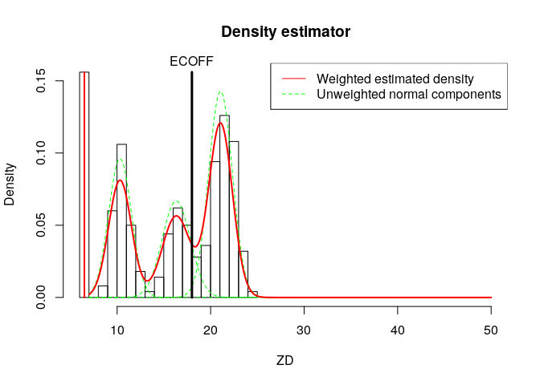

```r
plot(bayes.density,
     ECOFF = TRUE,
     quantile = 0.01,
     pi.level = 0.3)
```

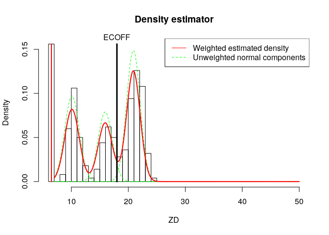

```r
plot(bayes.density.with.prior,
     ECOFF = TRUE,
     quantile = 0.01,
     pi.level = 0.3)
```

# Data: EUCASTData

Get the data of the zone diameter from the external package `EUCASTData`.

```r
data("ZD", package = "EUCASTData")
```

The code for three examples is included. Due to the required run-times for larger samples only the results for the second example are included, while the other examples are not evaluated.

## Example 1:

For one example dataset, first only selected the antimicrobial and bacteria you are interested in. Afterwards, you can run you analysis using the following functions:

```r
data1 <- subset(ZD,
                Antimicrobial == "Ampicillin" &
                  Bacterium == "Escherichia coli",
                grepl("^Z", colnames(ZD)))
res1 <- TheBayesteApproach(data = data1)
FindECOFF(res1
          pi.level = 0.3,
          quantile = 0.01)
plot(res1,
     ECOFF = TRUE,
     quantile = 0.01,
     pi.level = 0.3)
```

## Example 2:

```r
data2 <- subset(ZD,
                Antimicrobial == "Piperacillin" &
                  Bacterium == "Escherichia coli",
                grepl("^Z", colnames(ZD)))
res2 <- TheBayesteApproach(data = data2)
```

```r
FindECOFF(res2,
          pi.level = 0.3,
          quantile = 0.01)
```

```
#> [1] 20
```

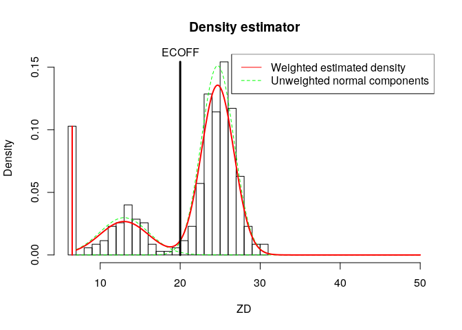

```r
plot(res2,
     ECOFF = TRUE,
     quantile = 0.01,
     pi.level = 0.3)
```

## Example 3:

```r
data3 <- subset(ZD,
                Antimicrobial == "Mecillinam" &
                  Bacterium == "Escherichia coli",
                grepl("^Z", colnames(ZD)))
res3 <- TheBayesteApproach(data = data3)
FindECOFF(res3,
          pi.level = 0.3,
          quantile = 0.01)
plot(res3,
     ECOFF = TRUE,
     quantile = 0.01,
     pi.level = 0.3)
```